# Predição de Recall a partir de Ocorrências de Garantia

- Mostrar o código
- Esconder o código
- Ver o código fonte

Parte 1 — Análise Exploratória e Qualidade dos Dados

Autor

Desafio técnico · Bolsista Cientista de Dados

Data de Publicação

20/08/2026

Resumo

Análise exploratória de 500 registros sintéticos de garantia, cobrindo avaliação de qualidade, estatística descritiva e estrutura de associação entre as variáveis. O documento estabelece o que o dado sustenta — e o que ele não sustenta — antes de qualquer decisão de modelagem.

## 1 Escopo e premissas

O objetivo desta etapa é responder três perguntas antes de treinar qualquer modelo: **o dado é confiável**, **o que ele descreve**, e **quais relações ele sustenta estatisticamente**. As decisões de limpeza registradas ao final desta análise são a especificação da etapa seguinte (`transform.py`) — nenhuma transformação é aplicada aqui.

Três premissas explícitas:

1. **Os dados são sintéticos**, conforme o enunciado. Nenhuma conclusão desta análise descreve a frota real da Stellantis; o que se avalia é o método.
2. **Não há chave primária nem coluna de data.** Cada linha é um veículo anônimo, e `idade_veiculo` é a única dimensão temporal disponível.
3. **`Recall` é o desfecho observado**, não uma previsão. O problema é de classificação binária supervisionada sobre quatro preditoras.

## 2 Origem e contrato do dado

A ingestão lê a planilha de origem, normaliza os cabeçalhos para `snake_case` sem acento e valida o resultado contra um contrato declarado em `pandera` (`RawSchema`). O contrato cobre tipo, obrigatoriedade e domínio de cada coluna — os limites de domínio são de **plausibilidade de negócio**, não o intervalo observado na amostra, para que uma carga futura com valores novos mas válidos não seja rejeitada por engano.

**código**

```python
df, relatorio = ingest.carregar_bruto()
con = eda.conectar(df)

print(relatorio.resumo())

pd.DataFrame(
    {
        "coluna": df.columns,
        "tipo": [str(t) for t in df.dtypes],
        "exemplo": [df[c].iloc[0] for c in df.columns],
    }
)
```

```
Contrato RawSchema: OK (500 linhas x 5 colunas).
```

Tabela 1: Resultado da validação do contrato de ingestão.

|  | coluna | tipo | exemplo |
| --- | --- | --- | --- |
| 0 | modelo | str | Strada |
| 1 | idade_veiculo | int64 | 3 |
| 2 | km | int64 | 46657 |
| 3 | reclamacoes | int64 | 1 |
| 4 | recall | str | Não |

A validação passa: 500 linhas, 5 colunas, nenhum valor fora de domínio e nenhum nulo. Isso é o *piso*, não o teto — o contrato garante estrutura, e a seção seguinte investiga as falhas de qualidade que um contrato estrutural não pega.

## 3 Avaliação de qualidade

### Perfil por coluna

**código**

```python
qualidade = eda.consultar(con, "qualidade_dados")
qualidade
```

Tabela 2: Perfil de preenchimento, cardinalidade e amplitude por coluna.

|  | coluna | natureza | n_linhas | n_preenchidos | n_nulos | n_distintos | minimo | maximo |
| --- | --- | --- | --- | --- | --- | --- | --- | --- |
| 0 | modelo | categorica | 500 | 500 | 0 | 9 | NaN | NaN |
| 1 | idade_veiculo | numerica | 500 | 500 | 0 | 9 | 0.0 | 8.0 |
| 2 | km | numerica | 500 | 500 | 0 | 494 | 1000.0 | 158294.0 |
| 3 | reclamacoes | numerica | 500 | 500 | 0 | 13 | 0.0 | 13.0 |
| 4 | recall | alvo | 500 | 500 | 0 | 2 | NaN | NaN |

Preenchimento integral em todas as colunas. Dois pontos de atenção na cardinalidade: `km` tem 494 valores distintos em 500 linhas — comportamento de variável contínua, coerente; `idade_veiculo` tem apenas 9 níveis (0 a 8), o que a torna, na prática, uma variável ordinal discreta e não contínua.

### Duplicatas

**código**

```python
duplicadas = eda.duplicatas(df)
duplicadas
```

Tabela 3: Linhas integralmente duplicadas.

|  | modelo | idade_veiculo | km | reclamacoes | recall | n_ocorrencias |
| --- | --- | --- | --- | --- | --- | --- |
| 0 | Renegade | 0 | 1000 | 3 | Não | 2 |

Existe **uma** linha repetida. Sem chave primária, ela é ambígua: pode ser o mesmo registro carregado duas vezes, ou dois veículos distintos que coincidem em todas as quatro características. O detalhe que decide a leitura é o valor de `km` — 1.000, exatamente o mínimo do dataset. Isso sugere colisão no piso do gerador sintético (dois veículos novos, ambos no limite inferior), e não erro de carga.

**Decisão:** remover a duplicata mesmo assim. Uma linha em 500 (0,2%) não altera nenhuma estatística de forma material, e mantê-la introduziria o mesmo registro em treino e teste na validação cruzada — um vazamento pequeno, porém gratuito. O critério aqui é de risco assimétrico, não de magnitude.

### Valores extremos

**código**

```python
outliers = eda.resumo_outliers(df)
outliers.assign(pct_outliers=pct(outliers["pct_outliers"]))
```

Tabela 4: Limites de Tukey (1,5 × IQR) e contagem de pontos fora deles.

|  | coluna | q1 | q3 | iqr | limite_inferior | limite_superior | n_outliers | pct_outliers |
| --- | --- | --- | --- | --- | --- | --- | --- | --- |
| 0 | idade_veiculo | 2.0 | 6.00 | 4.00 | -4.000 | 12.000 | 0 | 0.0% |
| 1 | km | 39322.5 | 105790.25 | 66467.75 | -60379.125 | 205491.875 | 0 | 0.0% |
| 2 | reclamacoes | 2.0 | 5.00 | 3.00 | -2.500 | 9.500 | 10 | 2.0% |

Nenhum extremo em `idade_veiculo` ou `km`. Em `reclamacoes`, 10 registros (2,0%) ficam acima do limite superior de 9,5 — são veículos com 10 a 13 reclamações.

**Decisão: não remover.** Esses registros são a cauda de uma distribuição de contagem assimétrica à direita (assimetria = 0,57), não erro de medição — e são justamente os veículos de maior interesse para o problema de negócio. Excluí-los removeria o sinal que o modelo precisa aprender. A cauda será tratada por transformação de escala na engenharia de atributos, se necessário.

### Coerência interna entre `km` e `idade_veiculo`

`km` e `idade_veiculo` são declarados de forma independente na origem. A razão entre eles — rodagem anual implícita — permite testar se as duas colunas contam a mesma história.

**código**

```python
km_ano = eda.consistencia_km_ano(df)

pd.DataFrame(
    {
        "métrica": [
            "veículos avaliados",
            "veículos com idade 0 (excluídos)",
            "km/ano — mínimo",
            "km/ano — mediana",
            "km/ano — máximo",
            f"fora da faixa plausível ({config.KM_ANO_MIN:,}–{config.KM_ANO_MAX:,})",
        ],
        "valor": [
            f"{len(km_ano)}",
            f"{(df['idade_veiculo'] == 0).sum()}",
            f"{km_ano['km_por_ano'].min():,.0f}",
            f"{km_ano['km_por_ano'].median():,.0f}",
            f"{km_ano['km_por_ano'].max():,.0f}",
            f"{int(km_ano['fora_da_faixa'].sum())}",
        ],
    }
)
```

Tabela 5: Rodagem anual implícita (veículos com idade ≥ 1 ano).

|  | métrica | valor |
| --- | --- | --- |
| 0 | veículos avaliados | 439 |
| 1 | veículos com idade 0 (excluídos) | 61 |
| 2 | km/ano — mínimo | 3,010 |
| 3 | km/ano — mediana | 18,491 |
| 4 | km/ano — máximo | 56,389 |
| 5 | fora da faixa plausível (2,000–60,000) | 0 |

Nenhum registro fora da faixa plausível. As duas colunas são internamente coerentes — e essa coerência tem consequência direta na modelagem, retomada na seção de multicolinearidade.

## 4 Estatística descritiva

### Variáveis numéricas

**código**

```python
eda.estatisticas_numericas(df).round(2)
```

Tabela 6: Descritivas estendidas: posição, dispersão e forma.

|  | n | media | desvio | minimo | 25% | mediana | 75% | maximo | cv | assimetria | curtose | iqr |
| --- | --- | --- | --- | --- | --- | --- | --- | --- | --- | --- | --- | --- |
| idade_veiculo | 500.0 | 3.93 | 2.63 | 0.0 | 2.0 | 4.0 | 6.00 | 8.0 | 0.67 | 0.04 | -1.25 | 4.00 |
| km | 500.0 | 73494.31 | 40846.02 | 1000.0 | 39322.5 | 70697.0 | 105790.25 | 158294.0 | 0.56 | 0.11 | -1.06 | 66467.75 |
| reclamacoes | 500.0 | 3.71 | 2.57 | 0.0 | 2.0 | 3.0 | 5.00 | 13.0 | 0.69 | 0.57 | -0.24 | 3.00 |

A curtose negativa de `idade_veiculo` (−1,26) e de `km` (−1,06) indica distribuições **achatadas**, próximas da uniforme, e não normais. É a assinatura esperada de dados gerados por amostragem uniforme — um indício, entre outros, de que a base é sintética e balanceada por construção. `reclamacoes` foge desse padrão: assimetria positiva de 0,57, típica de dado de contagem real.

### Variável categórica e alvo

**código**

```python
display(eda.estatisticas_categoricas(df))

alvo = eda.distribuicao_alvo(df)
display(alvo.assign(proporcao=pct(alvo["proporcao"])))
```

Tabela 7: Cardinalidade e concentração de `modelo`, e distribuição do alvo.

|  | coluna | n_categorias | moda | freq_moda | pct_moda | menor_categoria | freq_menor |
| --- | --- | --- | --- | --- | --- | --- | --- |
| 0 | modelo | 9 | Commander | 66 | 0.132 | Pulse | 48 |

|  | classe | n | proporcao |
| --- | --- | --- | --- |
| 0 | Não | 261 | 52.2% |
| 1 | Sim | 239 | 47.8% |

Os 9 modelos estão distribuídos de forma quase uniforme (48 a 66 veículos), sem categoria dominante nem categoria rara. O alvo está **praticamente balanceado**: 47,8% de recalls contra 52,2%.

**Consequência metodológica:** com classes balanceadas, *Accuracy* é uma métrica honesta neste problema — o classificador trivial atinge apenas 52,2%, então qualquer ganho sobre esse piso é informativo. Não há necessidade de reamostragem (SMOTE) nem de ponderação de classe. Precision, Recall e F1 continuam necessários, porém, pelo motivo oposto: o custo dos dois tipos de erro é assimétrico mesmo com as classes equilibradas.

### Distribuições por classe

**código**

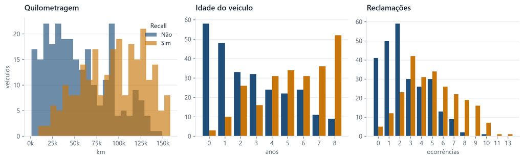

Figura 1: Distribuição de cada preditora, separada pelo desfecho de recall.

```python
fig, eixos = plt.subplots(1, 3, figsize=(11.5, 3.6))

grupos = [(rotulo, sub) for rotulo, sub in df.groupby(config.COLUNA_ALVO)]

# Km: contínua -> histograma sobreposto
for rotulo, sub in grupos:
    eixos[0].hist(
        sub["km"], bins=22, alpha=0.65,
        color=viz.CORES_ALVO[rotulo], label=rotulo,
    )
eixos[0].set_title("Quilometragem")
eixos[0].set_xlabel("km")
eixos[0].set_ylabel("veículos")
eixos[0].xaxis.set_major_formatter(
    plt.FuncFormatter(lambda v, _: f"{v/1000:.0f}k")
)

# Idade e reclamações: discretas -> barras agrupadas
for eixo, coluna, titulo in (
    (eixos[1], "idade_veiculo", "Idade do veículo"),
    (eixos[2], "reclamacoes", "Reclamações"),
):
    tabela = pd.crosstab(df[coluna], df[config.COLUNA_ALVO])
    posicoes = np.arange(len(tabela))
    largura = 0.42
    for deslocamento, rotulo in zip((-largura / 2, largura / 2), tabela.columns):
        eixo.bar(
            posicoes + deslocamento, tabela[rotulo], largura,
            color=viz.CORES_ALVO[rotulo], label=rotulo,
        )
    eixo.set_xticks(posicoes)
    eixo.set_xticklabels(tabela.index)
    eixo.set_title(titulo)
    eixo.set_xlabel("anos" if coluna == "idade_veiculo" else "ocorrências")

for eixo in eixos:
    viz.apenas_grade_horizontal(eixo)
eixos[0].legend(title="Recall")

fig.tight_layout()
plt.show()
```

O padrão é consistente nas três: veículos com recall concentram-se à direita em todas as preditoras. A separação é clara mas **não é limpa** — há sobreposição substancial em toda a faixa central, o que antecipa que nenhum modelo alcançará acurácia próxima de 100%.

## 5 Estrutura de associação

### Correlações

**código**

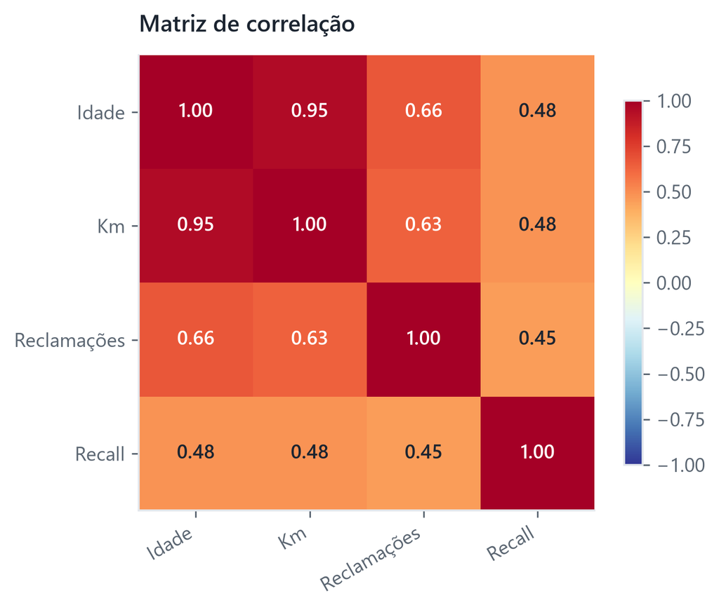

Figura 2: Correlação de Pearson entre preditoras numéricas e o alvo binarizado.

```python
matriz = eda.matriz_correlacao(df)
rotulos = ["Idade", "Km", "Reclamações", "Recall"]

fig, eixo = plt.subplots(figsize=(5.4, 4.4))
imagem = eixo.imshow(matriz, cmap="RdYlBu_r", vmin=-1, vmax=1)

eixo.set_xticks(range(len(rotulos)), rotulos, rotation=30, ha="right")
eixo.set_yticks(range(len(rotulos)), rotulos)
eixo.grid(False)

for i in range(len(rotulos)):
    for j in range(len(rotulos)):
        valor = matriz.iloc[i, j]
        eixo.text(
            j, i, f"{valor:.2f}", ha="center", va="center",
            color="white" if abs(valor) > 0.6 else viz.TINTA,
            fontsize=10, fontweight="semibold",
        )

eixo.set_title("Matriz de correlação")
fig.colorbar(imagem, ax=eixo, shrink=0.8)
fig.tight_layout()
plt.show()
```

**código**

```python
eda.correlacao_com_alvo(df).round(4)
```

Tabela 8: Correlação de cada preditora com o alvo (ponto-bisserial e Spearman).

|  | variavel | r_ponto_bisserial | p_valor | rho_spearman | p_valor_spearman | significante_5pct |
| --- | --- | --- | --- | --- | --- | --- |
| 0 | idade_veiculo | 0.4840 | 0.0 | 0.4849 | 0.0 | True |
| 1 | km | 0.4816 | 0.0 | 0.4835 | 0.0 | True |
| 2 | reclamacoes | 0.4521 | 0.0 | 0.4530 | 0.0 | True |

As três preditoras numéricas têm associação **moderada e estatisticamente significante** com o alvo, e de magnitude muito parecida entre si: 0,484 (idade), 0,482 (km) e 0,452 (reclamações). A concordância entre Pearson e Spearman indica que as relações são monotônicas, sem distorção por extremos.

Nenhuma preditora isolada explica o desfecho — o maior $r$ corresponde a $r^2 \approx 23\%$ da variância. O sinal existe e é real, mas exige combinação de variáveis.

### Multicolinearidade

**código**

```python
eda.fator_inflacao_variancia(df).round(2)
```

Tabela 9: Fator de inflação da variância (VIF) das preditoras numéricas.

|  | variavel | r2_contra_demais | vif |
| --- | --- | --- | --- |
| 0 | idade_veiculo | 0.90 | 10.39 |
| 1 | km | 0.90 | 9.71 |
| 2 | reclamacoes | 0.44 | 1.79 |

**Consequências diretas para a Parte 2:**

- **Regressão Logística** sem regularização terá coeficientes instáveis e de sinal potencialmente invertido. Os coeficientes deixam de ser interpretáveis individualmente, o que anula a principal vantagem do modelo. Se for usada, precisa de penalização L2 — e a interpretação passa a ser conjunta.
- **Modelos baseados em árvore** (Random Forest, XGBoost) são robustos à colinearidade na *predição*, mas não na *interpretação*: a importância se divide arbitrariamente entre as duas variáveis correlacionadas, subestimando ambas. Isso exige `permutation importance` por grupo, ou o descarte de uma delas, na Parte 4.
- **Alternativa a testar:** substituir o par por `idade_veiculo` + `km_por_ano`, que ortogonaliza a intensidade de uso em relação ao tempo de vida e preserva as duas dimensões sem redundância.

### `modelo` × `recall`: o ranking pedido tem base estatística?

O dashboard executivo (Parte 5) pede um *ranking de modelos de maior risco*. A pergunta anterior a essa é se as diferenças entre modelos são distinguíveis do acaso.

**código**

```python
teste = eda.qui_quadrado_com_alvo(df, "modelo")
print(teste.frase())

ranking = eda.consultar(con, "ranking_risco")
ranking.assign(
    taxa_recall=pct(ranking["taxa_recall"]),
    ic_inferior=pct(ranking["ic_inferior"]),
    ic_superior=pct(ranking["ic_superior"]),
).drop(columns=["amplitude_ic"])
```

```
chi2(8) = 6.69, p = 0.570, V de Cramer = 0.116 -- nao ha evidencia de associacao a 5%.
```

Tabela 10: Teste qui-quadrado de independência entre modelo e recall.

|  | posicao | modelo | n_veiculos | n_recalls | taxa_recall | ic_inferior | ic_superior |
| --- | --- | --- | --- | --- | --- | --- | --- |
| 0 | 1 | Toro | 54 | 31 | 57.4% | 44.2% | 69.7% |
| 1 | 2 | Cronos | 51 | 27 | 52.9% | 39.5% | 65.9% |
| 2 | 3 | Strada | 63 | 33 | 52.4% | 40.3% | 64.2% |
| 3 | 4 | Commander | 66 | 32 | 48.5% | 36.8% | 60.3% |
| 4 | 5 | Argo | 54 | 26 | 48.1% | 35.4% | 61.1% |
| 5 | 6 | Compass | 53 | 25 | 47.2% | 34.4% | 60.3% |
| 6 | 7 | Renegade | 52 | 23 | 44.2% | 31.6% | 57.7% |
| 7 | 8 | Pulse | 48 | 20 | 41.7% | 28.8% | 55.7% |
| 8 | 9 | Fastback | 59 | 22 | 37.3% | 26.1% | 50.0% |

**código**

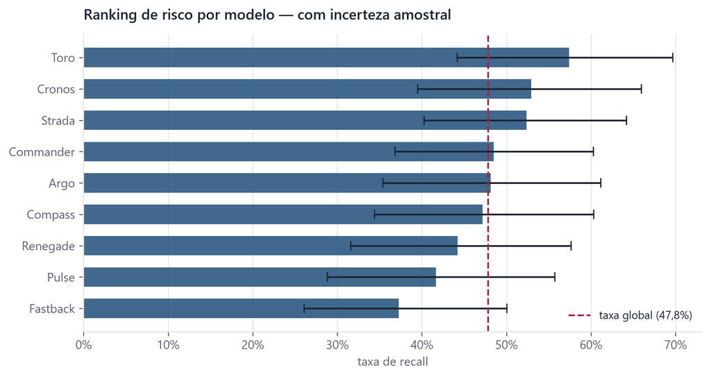

Figura 3: Taxa de recall por modelo, com intervalo de confiança de Wilson (95%). A linha tracejada marca a taxa global.

```python
ordenado = ranking.sort_values("taxa_recall")
posicoes = np.arange(len(ordenado))
erro = np.vstack([
    ordenado["taxa_recall"] - ordenado["ic_inferior"],
    ordenado["ic_superior"] - ordenado["taxa_recall"],
])

fig, eixo = plt.subplots(figsize=(8.2, 4.4))
eixo.barh(posicoes, ordenado["taxa_recall"], color=viz.AZUL, alpha=0.85, height=0.62)
eixo.errorbar(
    ordenado["taxa_recall"], posicoes, xerr=erro, fmt="none",
    ecolor=viz.TINTA, elinewidth=1.4, capsize=4,
)
eixo.axvline(
    eda.alvo_binario(df).mean(), color=viz.VERMELHO,
    linestyle="--", linewidth=1.4, label="taxa global (47,8%)",
)

eixo.set_yticks(posicoes, ordenado["modelo"])
eixo.set_xlabel("taxa de recall")
eixo.set_title("Ranking de risco por modelo — com incerteza amostral")
eixo.xaxis.set_major_formatter(plt.FuncFormatter(lambda v, _: f"{v:.0%}"))
eixo.grid(axis="y", visible=False)
eixo.legend(loc="lower right")

fig.tight_layout()
plt.show()
```

A causa é tamanho de amostra: cerca de 55 veículos por modelo produzem intervalos de ±13 pontos percentuais, largos demais para separar taxas que diferem em 20 pontos.

**Como isso será tratado na Parte 5:** o ranking será entregue, porque foi pedido — mas com as barras de erro visíveis e a ressalva explícita de que a ordenação é instável. Apresentar a tabela ordenada sem essa qualificação levaria a diretoria a priorizar inspeções em um modelo por ruído amostral. Este é o tipo de decisão que a análise existe para evitar.

### Gradiente de risco: reclamações e idade

Se `modelo` não discrimina, as variáveis contínuas discriminam?

**código**

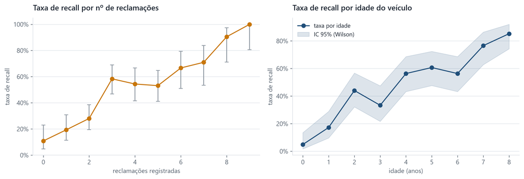

Figura 4: Taxa de recall por número de reclamações e por idade do veículo, com intervalo de Wilson (95%).

```python
por_reclamacoes = eda.taxa_por_grupo(df, "reclamacoes")
evolucao = eda.consultar(con, "evolucao_por_idade")
inf_idade, sup_idade = eda.intervalo_wilson(
    evolucao["n_recalls"], evolucao["n_veiculos"]
)

fig, (esq, dir) = plt.subplots(1, 2, figsize=(11.5, 4.0))

# Reclamações — apenas níveis com massa amostral suficiente para leitura
robustos = por_reclamacoes[por_reclamacoes["n"] >= 10]
esq.errorbar(
    robustos["reclamacoes"], robustos["taxa_recall"],
    yerr=np.vstack([
        robustos["taxa_recall"] - robustos["ic_inferior"],
        robustos["ic_superior"] - robustos["taxa_recall"],
    ]),
    fmt="o-", color=viz.AMBAR, ecolor=viz.CINZA,
    elinewidth=1.2, capsize=3, markersize=6,
)
esq.set_title("Taxa de recall por nº de reclamações")
esq.set_xlabel("reclamações registradas")
esq.set_ylabel("taxa de recall")
viz.rotular_percentual(esq)

# Idade
dir.plot(
    evolucao["idade_veiculo"], evolucao["taxa_recall"],
    "o-", color=viz.AZUL, markersize=6, label="taxa por idade",
)
dir.fill_between(
    evolucao["idade_veiculo"], inf_idade, sup_idade,
    color=viz.AZUL, alpha=0.15, label="IC 95% (Wilson)",
)
dir.set_title("Taxa de recall por idade do veículo")
dir.set_xlabel("idade (anos)")
dir.set_ylabel("taxa de recall")
viz.rotular_percentual(dir)
dir.legend(loc="upper left")

for eixo in (esq, dir):
    viz.apenas_grade_horizontal(eixo)

fig.tight_layout()
plt.show()
```

Aqui o contraste com `modelo` é gritante. A taxa de recall sobe de **4,9% aos 0 anos para 85,2% aos 8 anos**, e de **10,9% com zero reclamações para acima de 70% a partir de 7 reclamações**. Os intervalos de confiança dos extremos não se tocam nem de longe — este é sinal genuíno, não ruído.

Duas observações finas:

## 6 Síntese e decisões

### Backlog de limpeza para `transform.py`

**código**

```python
pd.DataFrame(
    [
        ("Duplicata (1 linha)", "Remover", "Evita a mesma observação em treino e teste na validação cruzada."),
        ("Outliers em reclamações (10)", "Manter", "Cauda legítima de contagem; são os veículos de maior interesse."),
        ("Valores ausentes", "Nenhuma ação", "Não há nulos em nenhuma coluna."),
        ("Alvo Sim/Não", "Converter para booleano", "Contrato explícito da camada trusted; evita comparação por string."),
        ("modelo", "Tipar como categórica", "9 níveis fixos; reduz memória e habilita codificação consistente."),
        ("km × idade_veiculo", "Manter ambas na trusted", "Decisão de seleção pertence à modelagem, não à limpeza."),
    ],
    columns=["achado", "decisão", "justificativa"],
)
```

Tabela 11: Decisões de tratamento derivadas desta análise.

|  | achado | decisão | justificativa |
| --- | --- | --- | --- |
| 0 | Duplicata (1 linha) | Remover | Evita a mesma observação em treino e teste na ... |
| 1 | Outliers em reclamações (10) | Manter | Cauda legítima de contagem; são os veículos de... |
| 2 | Valores ausentes | Nenhuma ação | Não há nulos em nenhuma coluna. |
| 3 | Alvo Sim/Não | Converter para booleano | Contrato explícito da camada trusted; evita co... |
| 4 | modelo | Tipar como categórica | 9 níveis fixos; reduz memória e habilita codif... |
| 5 | km × idade_veiculo | Manter ambas na trusted | Decisão de seleção pertence à modelagem, não à... |

### O que a Parte 1 estabelece para a modelagem

1. **O dado é estruturalmente limpo.** Sem nulos, sem inconsistências entre colunas, uma única duplicata. O esforço da entrega deve ir para validação e interpretação, não para saneamento.
2. **Há sinal real, moderado e distribuído.** Três preditoras com $r \approx 0{,}45$–$0{,}48$ e nenhuma dominante. O problema não é trivial nem determinístico, e a sobreposição visível nas distribuições impõe um erro irredutível substancial: nenhuma combinação de variáveis separa as duas classes na faixa central.

   **NotaConfronto com o resultado medido na Parte 2**

   A primeira versão desta seção estimava um teto de acurácia entre 78% e 84%, extrapolado das correlações marginais. **A medição desmentiu a estimativa.** Sob validação cruzada estratificada repetida (5×5), a melhor acurácia obtida entre todas as combinações de modelo e atributos foi de **70,5%**, e o modelo selecionado alcança **69,1%** (IC 95%: 67,2%–70,9%) — contra o piso de 52,1% do classificador trivial.

   O erro da estimativa original tem causa identificável: correlação marginal mede associação linear de cada variável isoladamente, e somá-las mentalmente ignora que as três são fortemente correlacionadas entre si. Com $\text{corr}(\text{idade}, \text{km}) = 0{,}947$, elas carregam em boa medida a *mesma* informação, e o poder preditivo conjunto fica muito abaixo da soma das partes.

   O registro fica no relatório em vez de ser apagado: a estimativa era uma inferência razoável a partir do que a Parte 1 tinha em mãos, e a diferença entre ela e o valor medido é, ela própria, um resultado sobre a estrutura dos dados.
3. **A colinearidade de 0,947 é a principal restrição técnica** e precisa ser endereçada explicitamente na escolha e na interpretação do modelo.
4. **`modelo` não é preditor útil** — e essa conclusão negativa é um resultado, não uma lacuna. Ela redireciona a recomendação executiva de “qual modelo inspecionar” para “qual perfil de uso inspecionar”.
5. **Com classes balanceadas**, as quatro métricas pedidas são aplicáveis sem ressalva, e o ponto de corte deve ser definido por custo de negócio — não pelo limiar implícito de 0,5.

**Limitação transversal.** Os dados são sintéticos e, como mostram a curtose negativa de `idade` e `km` e a coerência perfeita entre as duas colunas, foram gerados por regras simples. Um modelo ajustado aqui mede a capacidade de recuperar essas regras, não a de prever recalls reais. As quatro preditoras disponíveis também omitem dimensões que dominariam o problema real: fornecedor de componente, planta e lote de produção, tipo e severidade da falha, e a data da ocorrência. Isso está detalhado na Parte 4.